# Reproducible Research - Course Project 1

Ryan Maxfield

June 8, 2018

# Data

Dataset: https://d396qusza40orc.cloudfront.net/repdata%2Fdata%2Factivity.zip

Dataset variables:

```
    .       steps - Number of steps taken in 5-minute intervals

    .       date - Date the measurement was taked YYYY-MM-DD format

    .       interval - Identifies the 5-minute interval
```

Dataset is stored as .csv and contains a total of 17,568 observations

## 1. Code for reading in the dataset and/or processing the data

Obtain and load the dataset

```r
if(!file.exists("repdata%2FData%2Factivity.zip")) {
        temp<-tempfile()
        download.file("https://d396qusza40orc.cloudfront.net/repdata%2Fdata%2Factivity.zip",temp)
        unzip(temp)
        unlink(temp)
}

dx<-read.csv("activity.csv")
dz<-dx
```

## 2. Histogram of the total number of steps taken each day

Aggregate data and obtain the total number of steps per day and graph using ggplot2

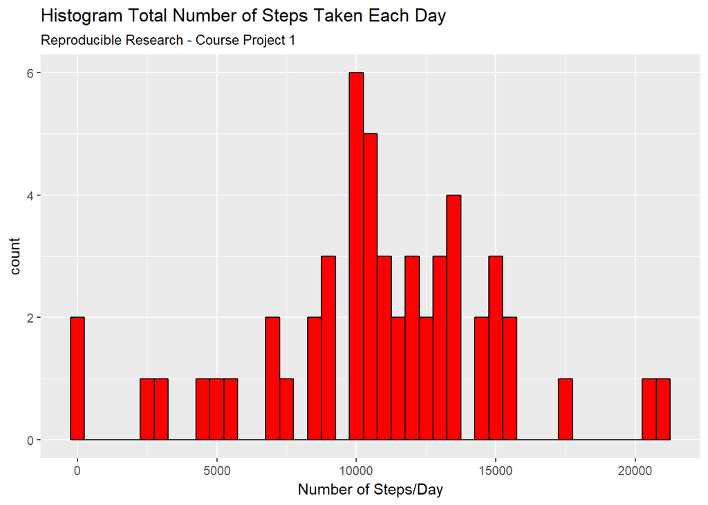

```r
da<-aggregate(steps~date,dx,sum)
library(ggplot2)
g<-ggplot(da,aes(steps))
g+geom_histogram(binwidth = 500,color="black",fill="red")+
        xlab("Number of Steps/Day")+
        ggtitle("Histogram Total Number of Steps Taken Each Day",subtitle="Reproducible Research - Course Project 1")
```

## 3. Mean and median number of steps taken each day

Mean and median number of steps per day available using in summary

```r
summary(da$steps)
```

```
##    Min. 1st Qu.  Median    Mean 3rd Qu.    Max.
##      41    8841   10765   10766   13294   21194
```

## 4. Time series plot of the average number of steps taken

Aggregate data and obtain the average number of steps per 5-minute period and graph using ggplot2

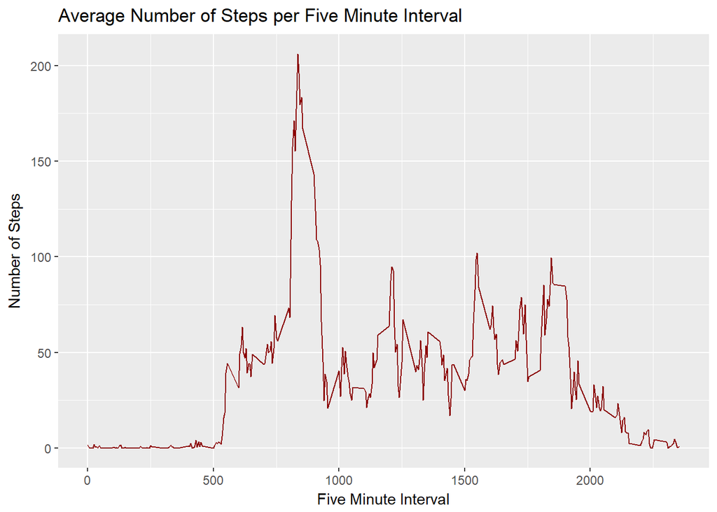

```r
db<-aggregate(steps~interval,dx,mean,na.rm=TRUE)
h<-ggplot(db,aes(interval,steps))
h+geom_line(color="darkred")+
        xlab("Five Minute Interval")+
        ylab("Number of Steps")+
        ggtitle("Average Number of Steps per Five Minute Interval")
```

## 5. The 5-minute interval that, on average, contains the maximum number of steps

Determine the 5-minute interval with the average maximum number of steps

```r
db[which.max(db$steps),1]
```

```
## [1] 835
```

## 6. Code to describe and show strategy for imputing missing data

Determine number of missing values

```r
sum(is.na(dx$steps))
```

```
## [1] 2304
```

Where no data is available replace with the calculated average (mean) using tapply

```r
dx$date<-as.Date(dx$date,"%m/%d/%Y")
index<-which(is.na(dx$steps))
l<-length(index)
avg<-with(dx,tapply(steps,date,mean,na.rm=TRUE))
dy<-mean(avg,na.rm=TRUE)
for(i in 1:l){
        dx[index[i],1]<-dy
}
```

Aggregate data and obtain the total number of steps per day and graph using ggplot2

[figure not shown]

```r
dc<-aggregate(steps~date,dz,sum)
library(ggplot2)
g<-ggplot(dc,aes(steps))
g+geom_histogram(binwidth = 500,color="black",fill="red")+
        xlab("Number of Steps/Day")+
        ggtitle("Histogram Total Number of Steps Taken Each Day (Imputed)",subtitle="Reproducible Research - Course Project 1")
```

## 8. Panel plot comparing the average number of steps taken per 5-minute interval across weekdays and weekends

Use xyplot function from lattice library

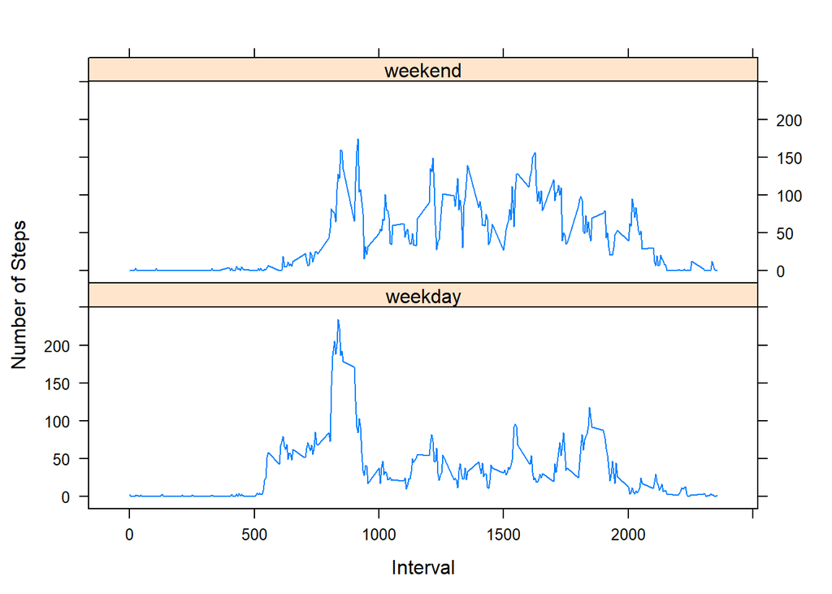

```r
dz$date <- as.Date(strptime(dz$date, format="%Y-%m-%d"))
dz$day <- weekdays(dz$date)
for (i in 1:nrow(dx)) {
    if (dz[i,]$day %in% c("Saturday","Sunday")) {
        dz[i,]$day<-"weekend"
    }
    else{
        dz[i,]$day<-"weekday"
    }
}
dwk<-aggregate(dz$steps~dz$interval+dz$day,dz,mean)
names(dwk)<-c("interval","day","steps")
library(lattice)
xyplot(steps~interval|day,dwk,type="l",layout=c(1, 2),
    xlab="Interval",ylab="Number of Steps")
```